# FIG Analysis Update

03 23 2022

## Narrative

- year 1: Plant IWG in fall
- year 2: IWG establishes, is harveseted once for grain
- year 3 + 4: IWG is treated as a forage
- *how should we manage the IWG in years 3 and 4?*
- *when should we harvest?*
- *how many times should we harvest?*

## Design

| Site | Planted | Data collected |
| --- | --- | --- |
| I2 | 2011 | 2017 |
| R70 | 2015 | 2017-2018 |
| R100 | 2016 | 2018-2019 |

- all sites in Rosemount MN

## Data collection

- response variables
  - yield
  - quality
    - **$**
- treatments
  - timing.1cut
    - boot, dough, anthesis, *grain*
  - follow.cut
    - none, sept, sept+oct
- sample times
  - 1.cut, 2.cut, 3.cut,
    - **.total**

## Site conditions 1

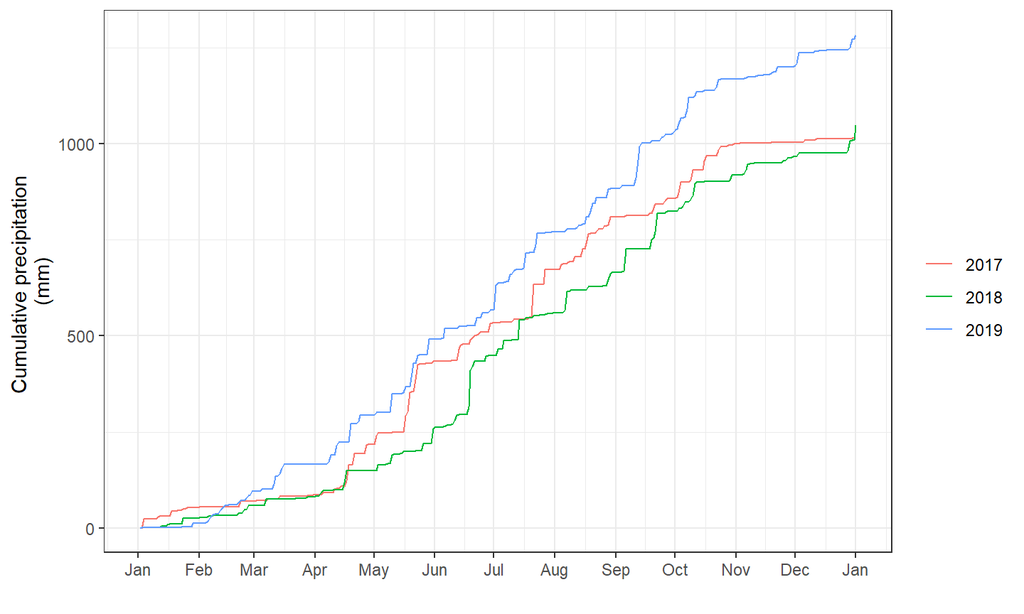

## Site conditions 2

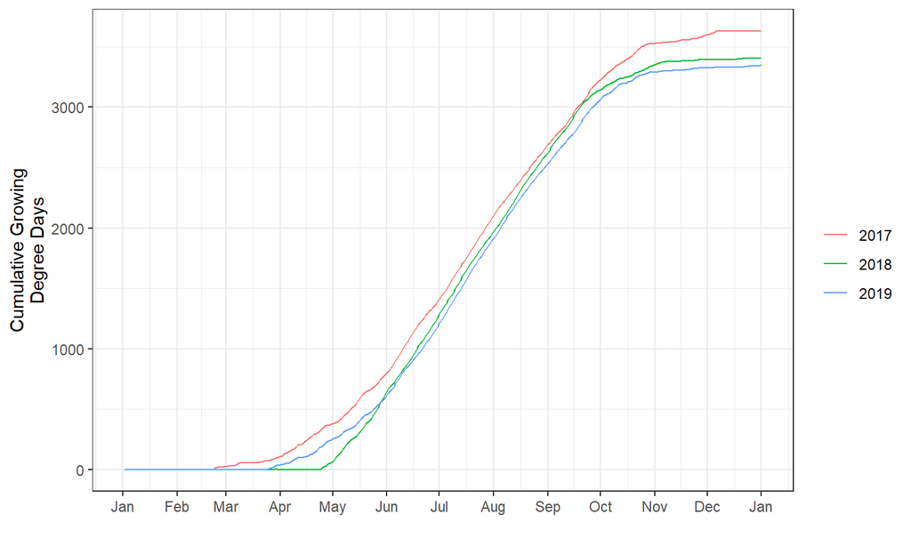

## Diagnostics

- missing data
  - grain cuts
  - follow-up cuts @ R70.2018 & I2.2017
- problematic data
  - one outlier value at R100.2019 for dough cut
  - I2

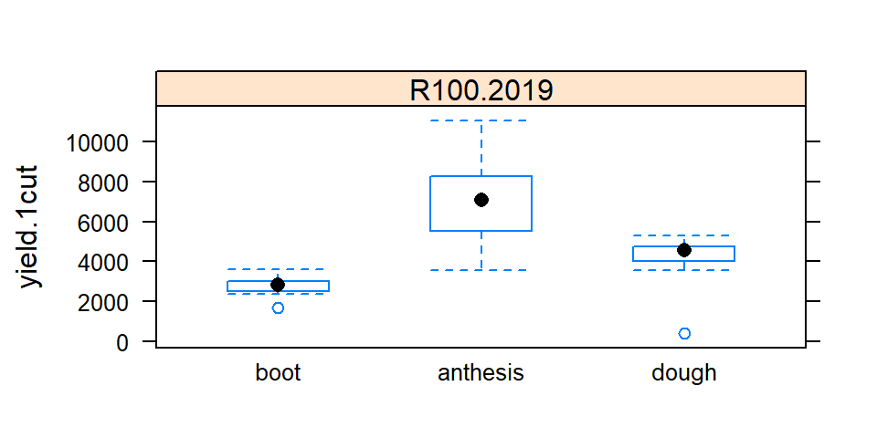

## I2 removal justification

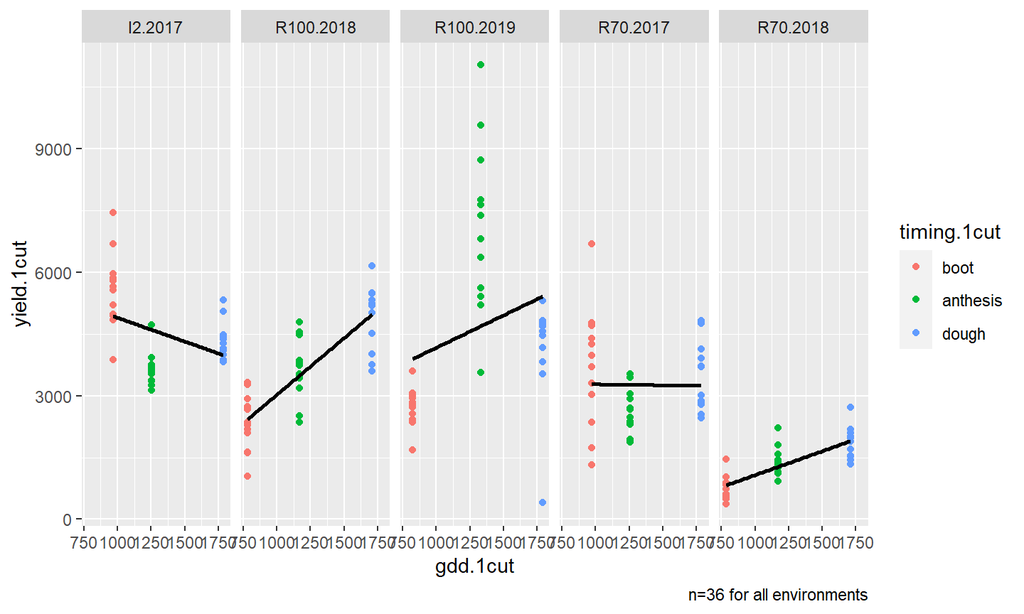

## Analysis 1

**null hypothesis testing**

- repeated measures
  - each plot is measured 1-3 times per year depending on assigned follow.cut treatment
  - each plot is measured over 2 consecutive years
- random effects
  - environment
  - site:block
- fixed effects
  - follow.cut
  - timing.1cut

## Analysis 2

**regression**

- responses vs.
  - GDD accumulation
  - *precipitation accumulation?*
  - *hydrothermal time?*

## Model fitting 1

- Box plot response by environment
  - identify if there’s a consistent trend
    - interaction drivers?
  - estimate distribution and variance
- Distribution
  - normal
    - lmer
  - gamma (poisson)
    - glmer

## Model fitting 2

- Fit all effects into model
  1. remove random effects not reducing residual variance
  2. compare multiple models
     - log liklihood
     - AIC
  3. null hypothesis test @ alpha=0.05
  4. post-hoc mean comparison
     - tukey, z-statistic

## yield of first cut in second year of data collection

```r
car::Anova(lmer(yield.1cut~follow.cut*timing.1cut+
                  (1|site:block)+
                  (1|env),
           data=subset(dat1, field.year=="second")))
```

```
## Analysis of Deviance Table (Type II Wald chisquare tests)
##
## Response: yield.1cut
##                          Chisq Df Pr(>Chisq)
## follow.cut              0.3972  2     0.8199
## timing.1cut            48.9246  2  2.378e-11 ***
## follow.cut:timing.1cut  1.1413  4     0.8877
## ---
## Signif. codes:  0 '***' 0.001 '**' 0.01 '*' 0.05 '.' 0.1 ' ' 1
```

## quality of first cut in second year of data collection

```r
car::Anova(lmer(RFQ.1cut~follow.cut*timing.1cut+
                  (1|site:block)+
                  (1|env),
           data=subset(dat1, field.year=="second")))
```

```
## Analysis of Deviance Table (Type II Wald chisquare tests)
##
## Response: RFQ.1cut
##                           Chisq Df Pr(>Chisq)
## follow.cut               0.5249  2     0.7692
## timing.1cut            165.1329  2     <2e-16 ***
## follow.cut:timing.1cut   6.2227  4     0.1831
## ---
## Signif. codes:  0 '***' 0.001 '**' 0.01 '*' 0.05 '.' 0.1 ' ' 1
```

## quality of second cut in second year

```r
car::Anova(lmer(RFQ.2cut~follow.cut*timing.1cut+
                  (1|block),
           data=subset(dat1, env=="R100.2019" & follow.cut!="none")))
```

```
## Analysis of Deviance Table (Type II Wald chisquare tests)
##
## Response: RFQ.2cut
##                         Chisq Df Pr(>Chisq)
## follow.cut             0.0577  1    0.81022
## timing.1cut            5.8500  2    0.05367 .
## follow.cut:timing.1cut 0.2704  2    0.87355
## ---
## Signif. codes:  0 '***' 0.001 '**' 0.01 '*' 0.05 '.' 0.1 ' ' 1
```

## quality of second cut in both years

```r
car::Anova(lmer(RFQ.2cut~year*follow.cut+
                  (1|block),
           data=subset(dat1, site=="R100" & follow.cut!="none")))
```

```
## Analysis of Deviance Table (Type II Wald chisquare tests)
##
## Response: RFQ.2cut
##                  Chisq Df Pr(>Chisq)
## year            1.1689  1     0.2796
## follow.cut      0.3024  1     0.5824
## year:follow.cut 0.1136  1     0.7361
```

-compare between years at same site since no obvious carryover effect -conclude that no difference in quality in second cut between the first and second year at R100.

## the effect of multiple cuttings

Second year datasets do not find differences among follow.cut treatment levels due to the follow.cut treatments applied in the first year.

| dataset | yield.1cut | rfq.1cut | .2cut | .3cut |
| --- | --- | --- | --- | --- |
| R70.2018+R100.2019 | ns | ns |  |  |
| R100.2019 |  |  | ns |  |

- no carryover effect from years observed

## follow.cut contribution to yield

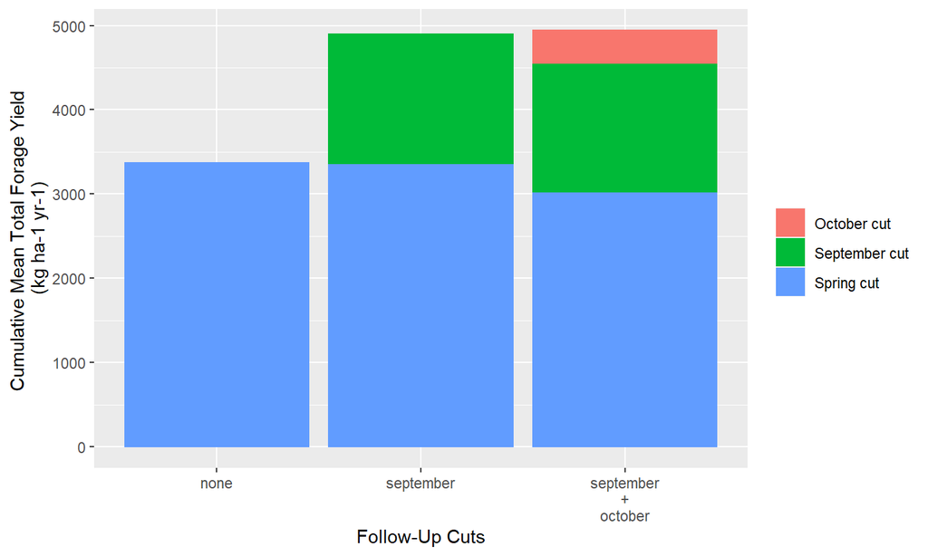

-NS differences

## follow.cut contribution to RFQ

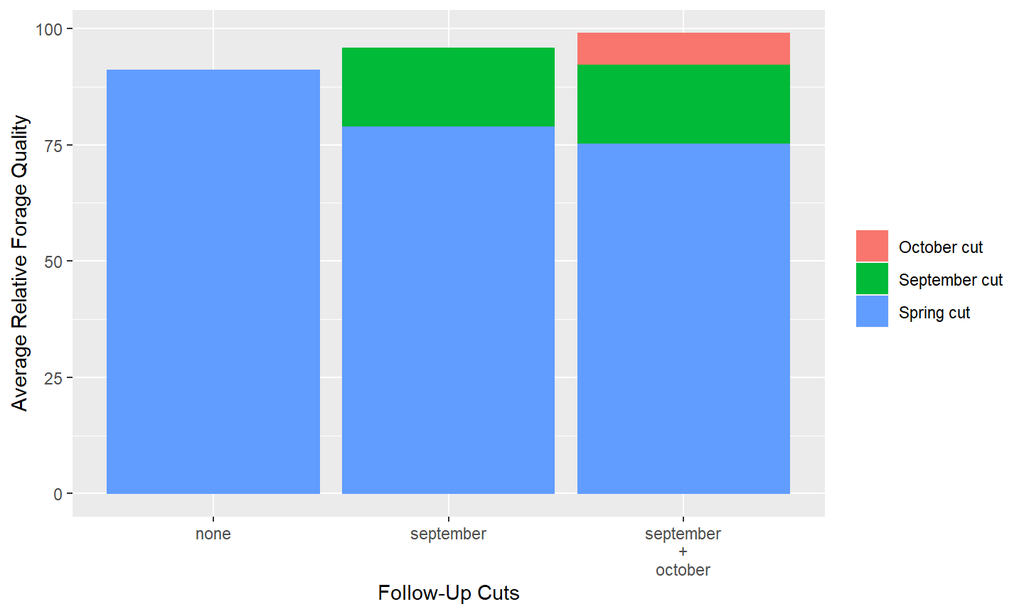

-NS differences

## yield.1cut vs. timing.1cut

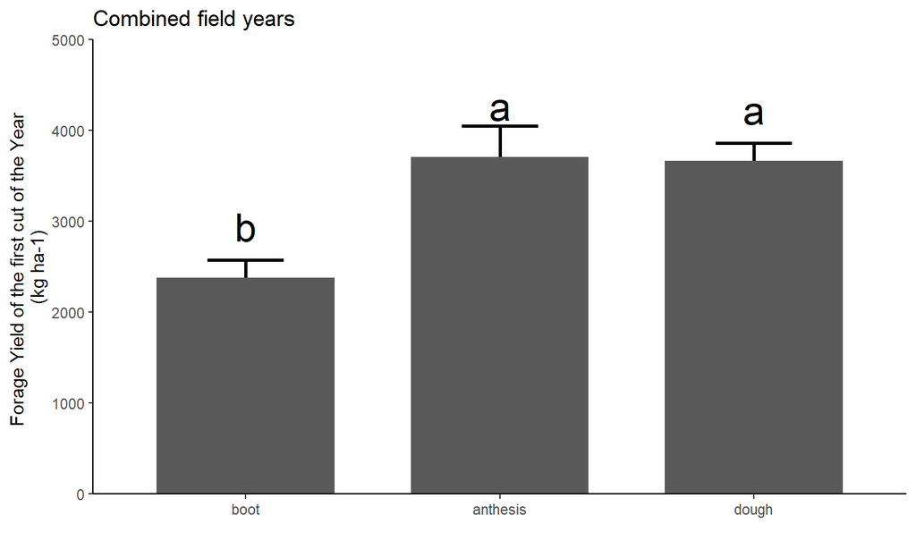

## yield.total vs. timing.1cut

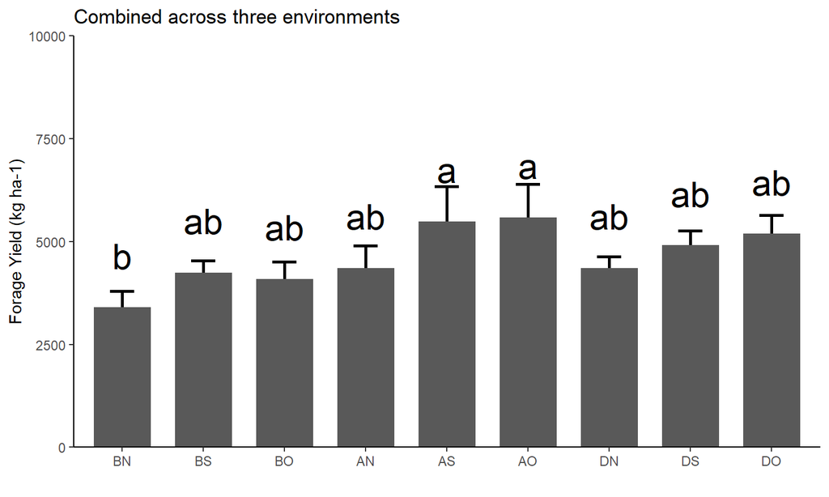

## rfq.1cut vs timing.1cut

[figure not shown]